## U.S. Population Estimate Analysis and Visualiztion

### 1.Introduction

This project used data from U.S. Census Bureau population Estimates(2020-2024) to explore population distribution and growth trends. I used the datasets to:

### 2.Load the dataset and data cleaning

```r
library(tidyverse)
```

```r
library(readr)
library(ggplot2)
csv_url <- "https://www2.census.gov/programs-surveys/popest/datasets/2020-2024/state/totals/NST-EST2024-ALLDATA.csv"
raw <- read_csv(csv_url, show_col_types = FALSE)
head(raw)
```

```
## # A tibble: 6 × 75
##   SUMLEV REGION DIVISION STATE NAME            ESTIMATESBASE2020 POPESTIMATE2020
##   <chr>  <chr>  <chr>    <chr> <chr>                       <dbl>           <dbl>
## 1 010    0      0        00    United States           331515736       331577720
## 2 020    1      0        00    Northeast Regi…          57617706        57431458
## 3 030    1      1        00    New England              15122011        15057350
## 4 030    1      2        00    Middle Atlantic          42495695        42374108
## 5 020    2      0        00    Midwest Region           68998970        68984258
## 6 030    2      3        00    East North Cen…          47381362        47358568
## # ℹ 68 more variables: POPESTIMATE2021 <dbl>, POPESTIMATE2022 <dbl>,
## #   POPESTIMATE2023 <dbl>, POPESTIMATE2024 <dbl>, NPOPCHG_2020 <dbl>,
## #   NPOPCHG_2021 <dbl>, NPOPCHG_2022 <dbl>, NPOPCHG_2023 <dbl>,
## #   NPOPCHG_2024 <dbl>, BIRTHS2020 <dbl>, BIRTHS2021 <dbl>, BIRTHS2022 <dbl>,
## #   BIRTHS2023 <dbl>, BIRTHS2024 <dbl>, DEATHS2020 <dbl>, DEATHS2021 <dbl>,
## #   DEATHS2022 <dbl>, DEATHS2023 <dbl>, DEATHS2024 <dbl>, NATURALCHG2020 <dbl>,
## #   NATURALCHG2021 <dbl>, NATURALCHG2022 <dbl>, NATURALCHG2023 <dbl>, …
```

```r
states <- raw %>%
  filter(NAME != "United States", STATE != 0)
states <- states %>%
  select(NAME, starts_with("POPESTIMATE"))
head(states)
```

```
## # A tibble: 6 × 6
##   NAME           POPESTIMATE2020 POPESTIMATE2021 POPESTIMATE2022 POPESTIMATE2023
##   <chr>                    <dbl>           <dbl>           <dbl>           <dbl>
## 1 Northeast Reg…        57431458        57252533        57159597        57398303
## 2 New England           15057350        15118145        15175633        15263573
## 3 Middle Atlant…        42374108        42134388        41983964        42134730
## 4 Midwest Region        68984258        68872831        68903297        69186401
## 5 East North Ce…        47358568        47206851        47199092        47360185
## 6 West North Ce…        21625690        21665980        21704205        21826216
## # ℹ 1 more variable: POPESTIMATE2024 <dbl>
```

### 3.Data Visualiztion

1-the plot shows the total population in US from 2020 to 2024. The population shows a steady and modest growth overtime.

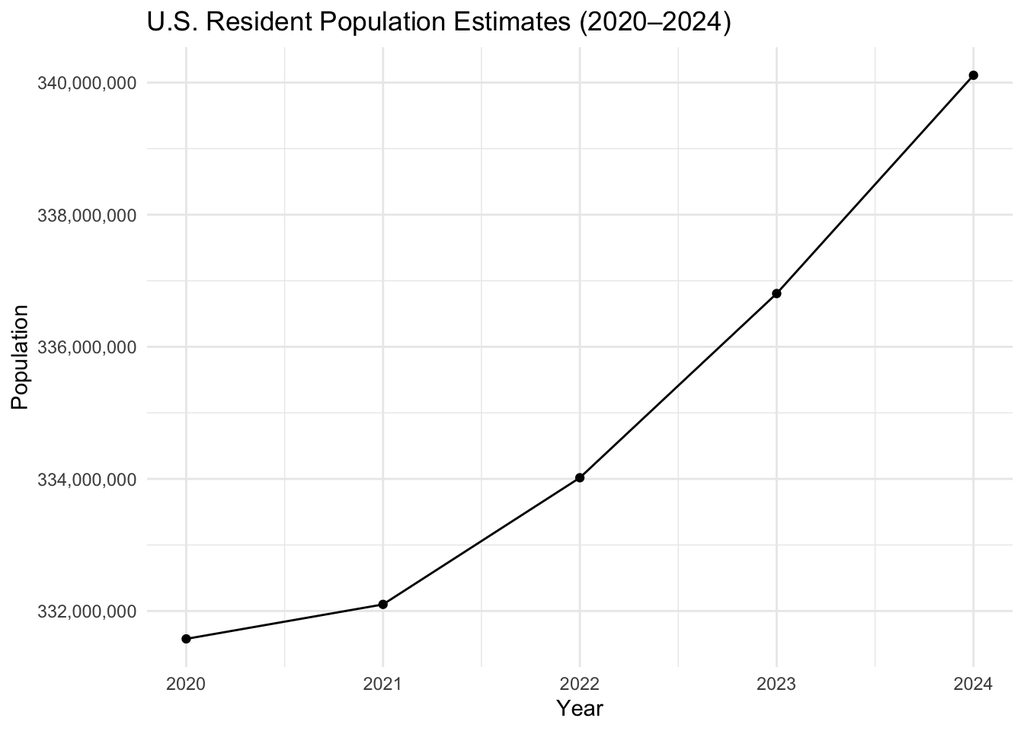

```r
us_long <- raw %>%
  filter(NAME == "United States") %>%
  pivot_longer(
    starts_with("POPESTIMATE"),
    names_to = "year",
    values_to = "population"
  ) %>%
  mutate(year = as.integer(str_remove(year, "POPESTIMATE")))
ggplot(us_long, aes(year, population)) +
  geom_line() +
  geom_point() +
  scale_y_continuous(labels = scales::comma) +
  labs(
    title = "U.S. Resident Population Estimates (2020–2024)",
    x = "Year",
    y = "Population"
  ) +
  theme_minimal()
```

2-The bar chart shows the Top 10 regions with most population in the US.

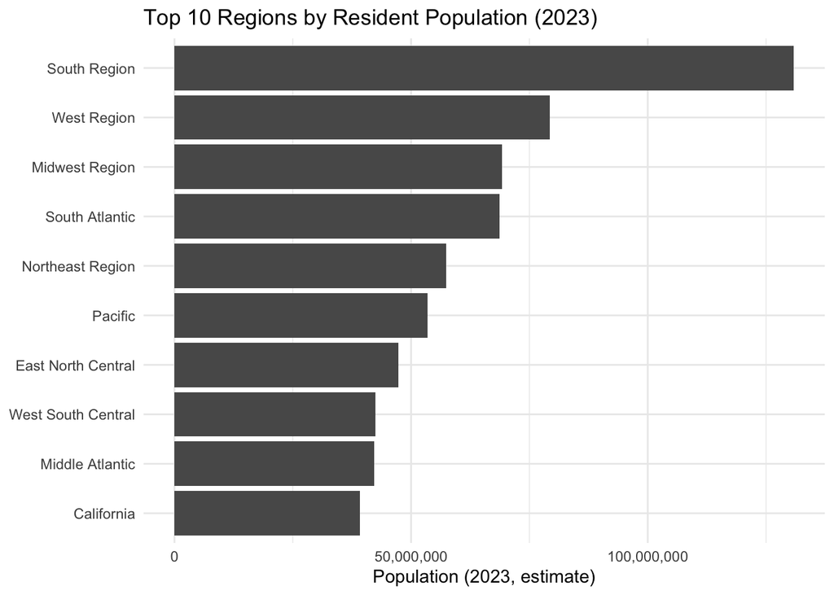

```r
states_2023 <- raw %>%
  filter(NAME != "United States", STATE != 0) %>%
  select(NAME, POPESTIMATE2023) %>%
  arrange(desc(POPESTIMATE2023)) %>%
  slice_head(n = 10) %>%
  mutate(NAME = forcats::fct_reorder(NAME, POPESTIMATE2023))
ggplot(states_2023, aes(x = NAME, y = POPESTIMATE2023)) +
  geom_col() +
  coord_flip() +
  scale_y_continuous(labels = scales::comma) +
  labs(
    title = "Top 10 Regions by Resident Population (2023)",
    x = NULL,
    y = "Population (2023, estimate)"
  ) +
  theme_minimal()
```

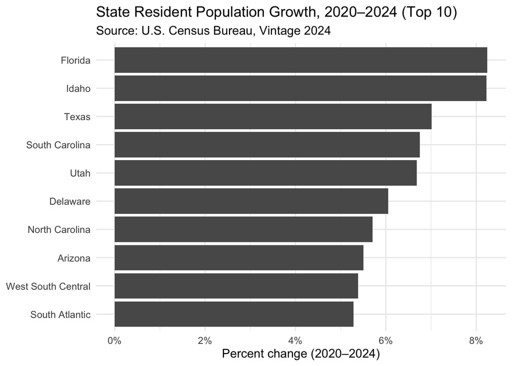

```r
growth_top10 <- raw %>%
  filter(NAME != "United States", STATE != 0) %>%
  transmute(
    NAME,
    pct_change = 100 * (POPESTIMATE2024 - POPESTIMATE2020) / POPESTIMATE2020
  ) %>%
  arrange(desc(pct_change)) %>%
  slice_head(n = 10) %>%
  mutate(NAME = fct_reorder(NAME, pct_change))
p_growth_top10 <- ggplot(growth_top10, aes(x = NAME, y = pct_change)) +
  geom_col() +
  coord_flip() +
  scale_y_continuous(labels = function(x) paste0(x, "%")) +
  labs(
    title = "State Resident Population Growth, 2020–2024 (Top 10)",
    subtitle = "Source: U.S. Census Bureau, Vintage 2024",
    x = NULL,
    y = "Percent change (2020–2024)"
  ) +
  theme_minimal(base_size = 12)
print(p_growth_top10)
```

### 4.Conclusion An analysis of the U.S. Census Bureau’s 2024 population estimates clearly reveals demographic trends between 2020 and 2024. The U.S. population experienced moderate but steady growth, with an estimated increase of several million people over the four years. However, at the state level, population distribution was uneven, with a few large states such as California, Texas, and Florida continuing to dominate the total population. The fastest population growth was observed in the Southern and Western states, this means that people are moving to areas with better economies, lower living costs, and warmer climates.